# Meta-analysis physiological costs of hibernation: Report 3 - GC

Pablo Capilla-Lasheras

2025-04-07

This [R Markdown](http://rmarkdown.rstudio.com) Notebook contains the initial meta-analysis for the project ‘physiological ’costs’ of hibernation.

## Dataset and calculation of effect sizes

The dataset for this meta-analysis has been collected after a literature search by Pablo Burraco, Marko Prokic and Tamara Petrovic. It contains data on physiological effects of hibernation in different systems. Here a quick snapshot of the first lines of the dataset:

|  | Reference | Year | Study_ID | Species | Family | Genus | Common.name | Type_of_animal | Thermoregulation | Class | Class_2 | Ver_Invert | Developmental_stage | Location | Experiment_venue | Biological.process | Tissue | Experimental_manipulation | Sex | Cortisol_or_corticosterone | Unit | Euthermia_N | Euthermia_M | Euthermia_SD | Euthermia_SE | Hib_N | Hib_M | Hib_SD | Hib_SE | … |
| --- | --- | --- | --- | --- | --- | --- | --- | --- | --- | --- | --- | --- | --- | --- | --- | --- | --- | --- | --- | --- | --- | --- | --- | --- | --- | --- | --- | --- | --- | --- |
| 1 | Dauphin-Villemant et al 1990 | 1990 | Study_765 | Zootoca vivipara | Lacertidae | Zootoca | Common lizard | Lizard | Ectotherm | Reptilia | NA | Vertebrate | Adult | France | Laboratory | Hibernation | Plasma | NA | Female | Corticosterone | ng/mL | 15 | 25.931034 | NA | 2.9425287 | 5 | 57.380224 | NA | 23.960234 | … |
| 2 | Dauphin-Villemant et al 1990 | 1990 | Study_765 | Zootoca vivipara | Lacertidae | Zootoca | Common lizard | Lizard | Ectotherm | Reptilia | NA | Vertebrate | Adult | France | Laboratory | Hibernation | Plasma | NA | Female | Corticosterone | ng/mL | 15 | 25.931034 | NA | 2.9425287 | 5 | 50.408159 | NA | 9.082635 | … |
| 3 | Dauphin-Villemant et al 1990 | 1990 | Study_765 | Zootoca vivipara | Lacertidae | Zootoca | Common lizard | Lizard | Ectotherm | Reptilia | NA | Vertebrate | Adult | France | Laboratory | Hibernation | Plasma | NA | Female | Corticosterone | ng/mL | 15 | 25.931034 | NA | 2.9425287 | 5 | 63.332944 | NA | 17.775081 | … |
| 4 | Dauphin-Villemant et al 1990 | 1990 | Study_765 | Zootoca vivipara | Lacertidae | Zootoca | Common lizard | Lizard | Ectotherm | Reptilia | NA | Vertebrate | Adult | France | Laboratory | Hibernation | Plasma | NA | Female | Corticosterone | ng/mL | 15 | 25.931034 | NA | 2.9425287 | 5 | 32.125271 | NA | 11.013979 | … |
| 5 | Dauphin-Villemant et al 1990 | 1990 | Study_765 | Zootoca vivipara | Lacertidae | Zootoca | Common lizard | Lizard | Ectotherm | Reptilia | NA | Vertebrate | Adult | France | Laboratory | Hibernation | Plasma | NA | Female | Corticosterone | ng/mL | 15 | 25.931034 | NA | 2.9425287 | 5 | 19.804439 | NA | 2.707055 | … |
| 6 | Dauphin-Villemant et al 1990 | 1990 | Study_765 | Zootoca vivipara | Lacertidae | Zootoca | Common lizard | Lizard | Ectotherm | Reptilia | NA | Vertebrate | Adult | France | Laboratory | Hibernation | Plasma | NA | Female | Corticosterone | ng/mL | 15 | 25.931034 | NA | 2.9425287 | 5 | 33.429325 | NA | 7.729108 | … |
| 7 | Dauphin-Villemant et al 1990 | 1990 | Study_765 | Zootoca vivipara | Lacertidae | Zootoca | Common lizard | Lizard | Ectotherm | Reptilia | NA | Vertebrate | Adult | France | Laboratory | Hibernation | Plasma | NA | Female | Corticosterone | ng/mL | 15 | 25.931034 | NA | 2.9425287 | 5 | 41.195402 | NA | 6.068966 | … |
| 8 | Dauphin-Villemant et al 1990 | 1990 | Study_765 | Zootoca vivipara | Lacertidae | Zootoca | Common lizard | Lizard | Ectotherm | Reptilia | NA | Vertebrate | Adult | France | Laboratory | Hibernation | Plasma | NA | Female | Corticosterone | ng/mL | 15 | 25.931034 | NA | 2.9425287 | 5 | 62.712644 | NA | 4.965517 | … |
| 9 | Dauphin-Villemant et al 1990 | 1990 | Study_765 | Zootoca vivipara | Lacertidae | Zootoca | Common lizard | Lizard | Ectotherm | Reptilia | NA | Vertebrate | Adult | France | Laboratory | Hibernation | Plasma | NA | Female | Corticosterone | ng/mL | 15 | 25.931034 | NA | 2.9425287 | 12 | 75.954023 | NA | 6.620690 | … |
| 10 | Dauphin-Villemant et al 1990 | 1990 | Study_765 | Zootoca vivipara | Lacertidae | Zootoca | Common lizard | Lizard | Ectotherm | Reptilia | NA | Vertebrate | Adult | France | Laboratory | Hibernation | Plasma | NA | Female | Corticosterone | ng/mL | 15 | 25.931034 | NA | 2.9425287 | 5 | 57.563218 | NA | 13.977011 | … |

[output cut: 108 more lines]

As a summary of the *initial dataset*:

- Number of studies: 19
- Number of species: 16

For this meta-analysis, I am going to include all glucocorticoid (GC) measures and calculate the standarised mean difference (g) as the effect size of analysis comparing **hibernation** *versus* **euthermia**. Positive SMD values indicate higher GC values in *hibernation* while negative SMD indicate lower GC values in hibernation. This is a summary of the effect size calculation based on the dataset above:

Summary of SMD effect size and number of observations included in the meta-analysis:

```
##    Min. 1st Qu.  Median    Mean 3rd Qu.    Max.
## -9.1685 -0.2169  0.7684  0.4842  1.4328  4.8164
```

- Number of observation with non-missing SMD: 95
- Number of studies in the dataset for analysis: 18
- Number of species in the dataset for analysis: 16

## Initial meta-analysis:

This initial model contains only the intercept and five random effects to account for variation between between classes, families, species, between studies and within studies beyond sampling variance.

```r
model_SMD <- rma.mv(yi = SMDH,
                     V = SMDH.sv,
                     mods = ~ 1,
                     random = list(~1|Study_ID,
                                   ~1|Class,
                                   ~1|Family,
                                   ~1|Species,
                                   ~1|obsID),
                     data=df_SMD,
                     method="REML")
```

```
##
## Multivariate Meta-Analysis Model (k = 95; method: REML)
##
##    logLik   Deviance        AIC        BIC       AICc
## -153.1185   306.2369   318.2369   333.4967   319.2025
##
## Variance Components:
##
##             estim    sqrt  nlvls  fixed    factor
## sigma^2.1  0.0739  0.2719     18     no  Study_ID
## sigma^2.2  0.0000  0.0006      4     no     Class
## sigma^2.3  3.9784  1.9946     10     no    Family
## sigma^2.4  0.3535  0.5945     16     no   Species
## sigma^2.5  0.4277  0.6540     95     no     obsID
##
## Test for Heterogeneity:
## Q(df = 94) = 465.5950, p-val < .0001
##
## Model Results:
##
## estimate      se    zval    pval    ci.lb   ci.ub
##   0.4272  0.6886  0.6204  0.5350  -0.9224  1.7768
##
## ---
## Signif. codes:  0 '***' 0.001 '**' 0.01 '*' 0.05 '.' 0.1 ' ' 1
```

Proportion of variation left after accounting for sampling variance and proportion accounted by each random effect:

| Variable | i2_value_percentage |
| --- | --- |
| I2_Total | 93.535 |
| I2_Study_ID | 1.431 |
| I2_Class | 0.000 |
| I2_Family | 76.988 |
| I2_Species | 6.840 |
| I2_obsID | 8.276 |

### Plot of results of intercept-only model:

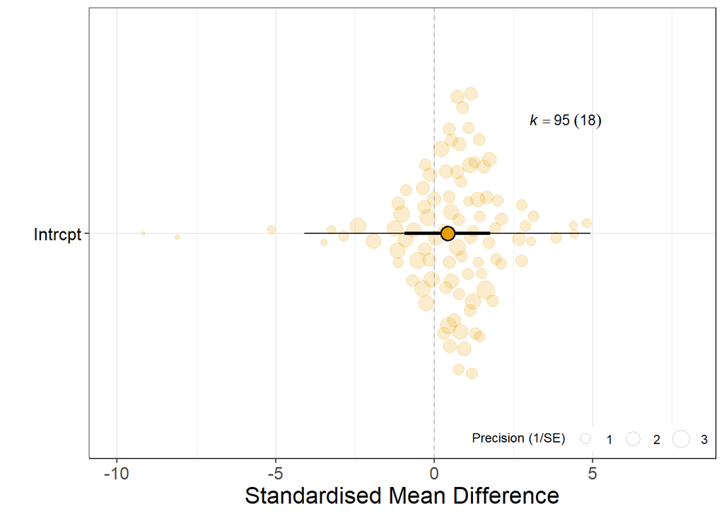

### Publication bias: small-study effects

```
##
## Multivariate Meta-Analysis Model (k = 95; method: REML)
##
##    logLik   Deviance        AIC        BIC       AICc
## -151.5740   303.1479   317.1479   334.8761   318.4656
##
## Variance Components:
##
##             estim    sqrt  nlvls  fixed    factor
## sigma^2.1  0.0176  0.1326     18     no  Study_ID
## sigma^2.2  0.0290  0.1704      4     no     Class
## sigma^2.3  3.9356  1.9838     10     no    Family
## sigma^2.4  0.3909  0.6252     16     no   Species
## sigma^2.5  0.4464  0.6681     95     no     obsID
##
## Test for Residual Heterogeneity:
## QE(df = 93) = 439.9161, p-val < .0001
##
## Test of Moderators (coefficient 2):
## QM(df = 1) = 0.8756, p-val = 0.3494
##
## Model Results:
##
##                   estimate      se     zval    pval    ci.lb   ci.ub
## intrcpt            -0.1513  0.9322  -0.1623  0.8711  -1.9784  1.6758
## sqrt(inv_eff_ss)    1.1227  1.1997   0.9358  0.3494  -1.2288  3.4741
##
## ---
## Signif. codes:  0 '***' 0.001 '**' 0.01 '*' 0.05 '.' 0.1 ' ' 1
```

```
##    R2_marginal R2_conditional
##    0.003452881    0.907694549
```

### Publication bias: time-lag effects

```
##
## Multivariate Meta-Analysis Model (k = 95; method: REML)
##
##    logLik   Deviance        AIC        BIC       AICc
## -150.6420   301.2841   315.2841   333.0123   316.6017
##
## Variance Components:
##
##             estim    sqrt  nlvls  fixed    factor
## sigma^2.1  0.0000  0.0000     18     no  Study_ID
## sigma^2.2  0.0000  0.0003      4     no     Class
## sigma^2.3  4.2191  2.0540     10     no    Family
## sigma^2.4  0.2363  0.4861     16     no   Species
## sigma^2.5  0.4493  0.6703     95     no     obsID
##
## Test for Residual Heterogeneity:
## QE(df = 93) = 463.5546, p-val < .0001
##
## Test of Moderators (coefficient 2):
## QM(df = 1) = 2.1786, p-val = 0.1399
##
## Model Results:
##
##              estimate      se    zval    pval    ci.lb   ci.ub
## intrcpt        0.4109  0.6958  0.5906  0.5548  -0.9529  1.7748
## scale(Year)    0.3532  0.2393  1.4760  0.1399  -0.1158  0.8221
##
## ---
## Signif. codes:  0 '***' 0.001 '**' 0.01 '*' 0.05 '.' 0.1 ' ' 1
```

```
##    R2_marginal R2_conditional
##     0.02480049     0.91067371
```

## Meta-analysis including thermoregulation type as a moderator:

Number of observations for each type:

```
##
## Ectotherm Endotherm
##        64        31
```

```
##
## Multivariate Meta-Analysis Model (k = 95; method: REML)
##
##    logLik   Deviance        AIC        BIC       AICc
## -149.4367   298.8734   312.8734   330.6016   314.1911
##
## Variance Components:
##
##             estim    sqrt  nlvls  fixed    factor
## sigma^2.1  0.0746  0.2731     18     no  Study_ID
## sigma^2.2  0.0000  0.0002      4     no     Class
## sigma^2.3  3.7666  1.9408     10     no    Family
## sigma^2.4  0.3331  0.5771     16     no   Species
## sigma^2.5  0.4291  0.6550     95     no     obsID
##
## Test for Residual Heterogeneity:
## QE(df = 93) = 463.4472, p-val < .0001
##
## Test of Moderators (coefficients 1:2):
## QM(df = 2) = 2.2635, p-val = 0.3225
##
## Model Results:
##
##                            estimate      se     zval    pval    ci.lb   ci.ub
## ThermoregulationEctotherm    1.1525  0.8557   1.3469  0.1780  -0.5246  2.8295
## ThermoregulationEndotherm   -0.7268  1.0842  -0.6704  0.5026  -2.8518  1.3981
##
## ThermoregulationEctotherm
## ThermoregulationEndotherm
##
## ---
## Signif. codes:  0 '***' 0.001 '**' 0.01 '*' 0.05 '.' 0.1 ' ' 1
```

```
##
## Multivariate Meta-Analysis Model (k = 95; method: REML)
##
##    logLik   Deviance        AIC        BIC       AICc
## -149.4367   298.8734   312.8734   330.6016   314.1911
##
## Variance Components:
##
##             estim    sqrt  nlvls  fixed    factor
## sigma^2.1  0.0746  0.2731     18     no  Study_ID
## sigma^2.2  0.0000  0.0002      4     no     Class
## sigma^2.3  3.7666  1.9408     10     no    Family
## sigma^2.4  0.3331  0.5771     16     no   Species
## sigma^2.5  0.4291  0.6550     95     no     obsID
##
## Test for Residual Heterogeneity:
## QE(df = 93) = 463.4472, p-val < .0001
##
## Test of Moderators (coefficients 1:2):
## QM(df = 2) = 2.2635, p-val = 0.3225
##
## Model Results:
##
##                            estimate      se     zval    pval    ci.lb   ci.ub
## ThermoregulationEctotherm    1.1525  0.8557   1.3469  0.1780  -0.5246  2.8295
## ThermoregulationEndotherm   -0.7268  1.0842  -0.6704  0.5026  -2.8518  1.3981
##
## ThermoregulationEctotherm
## ThermoregulationEndotherm
##
## ---
## Signif. codes:  0 '***' 0.001 '**' 0.01 '*' 0.05 '.' 0.1 ' ' 1
```

### Plot of results of thermoregulation meta-regression:

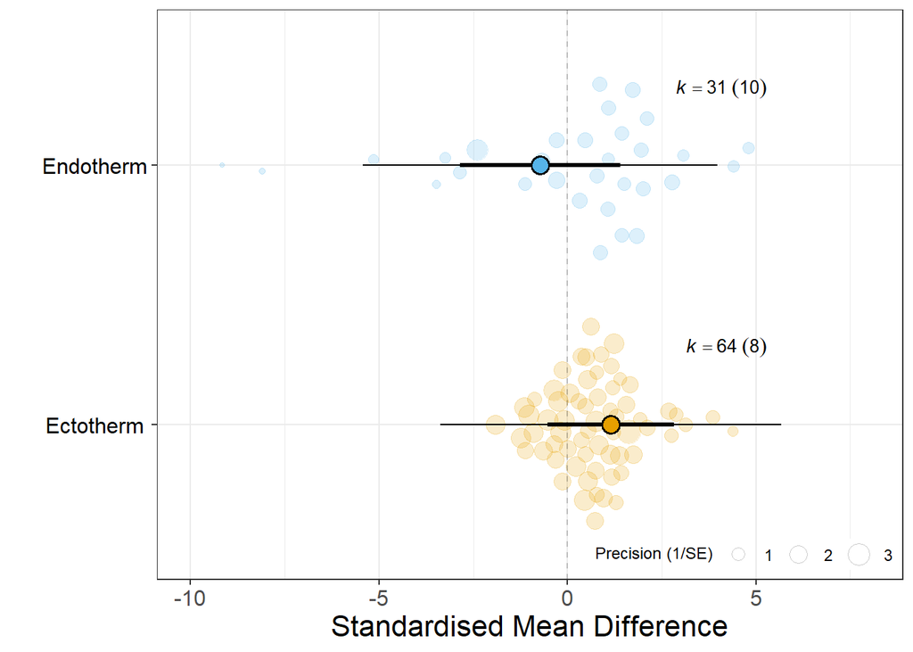